# homework3

Gabriele Pelliccioni, Salim Sikder, Mario Edoardo Pandolfo

2023-02-17

# 2 Friedman’s Paper

The paper is about the idea of reducing a multivariate two-sample test into a univariate one using a binary classifier.

The main concept is using a binary classifier as a scoring function by giving to each observation $\{x_i\}_{i=1}^N$ a score $F(x)$, that we’re going to use with an **univariate two-sample tests** as Kolmorogov-Smirnov or Mann-Whitney ones.

The main procedure can be summarized as:

1. Merge all the data of the two distribution in a single dataset: $\{x_i\}_{i=1}^N$ and $\{x_i\}_{i=1}^M$ to $\{u_i\}_{i=1}^{N+M}$.
2. Do the following sub-procedure:
   1. Train a classifier on all the new dataset with the labels.
   2. Score the observation using the classifier.
   3. Compute the final test statistic, and saving the result.
3. Because we’re using the entire dataset both in training and in the scoring section, we need to perform the permutation method to solve the *Type-I error*. We permute the labels because by being in the null hypothesis “The two distributions are the same the distributions” labels are not influential at all. In this step we re-do the sub-procedure defined at step 2 for $\mathcal{P}$ times, in which $\mathcal{P}$ is a sample of all the possible permutations of $(N+M)!$ such that $P<<(N+M)!$.
4. Finally we can calculate the **p-value** as $p=\frac{1}{n}\sum_{j=1}^N\mathbb{I}(T_j\ge T)$.
5. We reject $H_0$ when $p<\alpha$.

## 2.1 Auxiliary test adopted

Auxiliary tests are used to assess if two samples of data come from the same distribution. Usually they are used when the assumptions of parametric tests are violated, and the data is not normally distributed.

Two examples of auxiliary tests are:

- The **Kolmogorov-Smirnov test**, which calculates the maximum difference between the cumulative distribution functions (CDFs) of the two samples.
- The **Mann-Whitney test**, which compares the medians of two samples. It is also known as the Wilcoxon rank-sum test.

These tests, as said before, are useful when the assumptions of parametric tests are violated by the data (ex. normality or equal variances). It is worth noticing that both tests are also robust to outliers and are easy to understand and interpret.

# 3 Implementation of Friedman’s Paper

```r
library(MASS)
library(rpart)
generate_mu <- function(k){runif(k, -1, 1)}

generate_sigma <- function(k){
  p <- qr.Q(qr(matrix(rnorm(k^2), k)))
  Sigma <- crossprod(p, p*(k:1))
  return(Sigma)
}

n0 <- 250
n1 <- 250
k <- 10
N <- 100

M <- 10

simulation <- function(n0, n1, k, N, M){

  mu.0 <- generate_mu(k)
  mu.1 <- generate_mu(k)
  cov_mat.0 <- generate_sigma(k)
  cov_mat.1 <- generate_sigma(k)

  p.values <- rep(NA, M)
  for(m in 1:M){

    # create the two multivariate distributions
    F0.raw <- mvrnorm(n = n0,
                      mu = mu.0,
                      Sigma = cov_mat.0)

    F1.raw <- mvrnorm(n = n1,
                      mu = mu.1,
                      Sigma = cov_mat.1)

    #F1.raw <- rdirichlet(n1, runif(k, 0, k))

    # We save the data in DataFrames
    F0 <- data.frame(F0.raw)
    F1 <- data.frame(F1.raw)

    # Concatenate the two dataframes
    df <- rbind(F0, F1)

    df["Label"] = c(rep(0, n0), rep(1, n1))

    classifier <- rpart(Label ~ ., data = df, method = "class")

    df["Predicted"] <- predict(classifier, df, type = 'class')

    s0 <- as.numeric(df[df$Label == 0,]$Predicted)
    s1 <- as.numeric(df[df$Label == 1,]$Predicted)

    t.hat <- wilcox.test(s0, s1)$p.value

    test.vect <- rep(NA, N)

    # Permutation test
    for(n in 1:N){
      # We perform the random permutation of the labels
      df["Label"] = sample(c(rep(0, n0), rep(1, n1)))

      classifier <- rpart(Label ~ . - Predicted, data = df, method = "class")

      df["Predicted"] <- predict(classifier, df, type = 'class')

      s0 <- as.numeric(df[df$Label == 0,]$Predicted)
      s1 <- as.numeric(df[df$Label == 1,]$Predicted)

      test.vect[n] <- wilcox.test(s0, s1)$p.value
    }

    p.values[m] <- length(test.vect[test.vect >= t.hat])/N
  }

  return(p.values)

}
```

Unfortunately we had to set $M$ really low because the power of our computers was not enough. We have also saved all the p.values in a RData file for rendering the plot without running the simulation every time. Another parameter we could tune is $N$, the number of random permutations to consider, but we already know that the bigger is $N$ the better it is (ideally it should be $(n_0+n_1)!$), we took $N=100$ for the power of our computer.

```r
load("all_pvalues.RData")
```

## Simulation over $k$

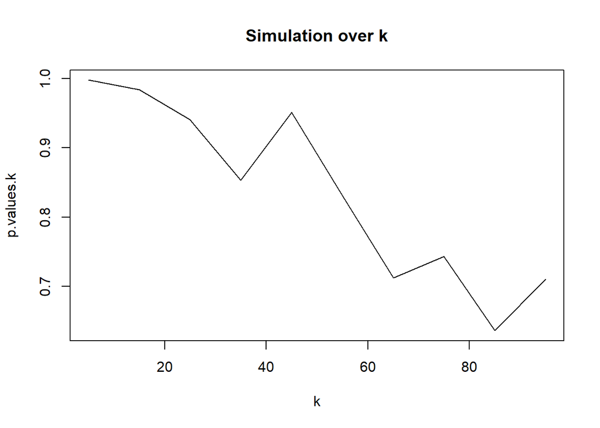

```r
# Simulation over k
p.values.k <- rep(NA, 10)
for(k in 1:10){
  p.values.k[k] <- mean(simulation(n0, n1, seq(10, 100, by=10)[k], N, M), na.rm=T)
}
plot(seq(5, 100, by=10), p.values.k, type="l", xlab="k", main="Simulation over k")
```

It seems that the more $k$ grows the more the p-value decrease, this could be due from the lack of observations:increasing the complexity of the distributions we need more data. We’ll look forward to check the truthfulness of this statement.

## Simulation over $n_1$

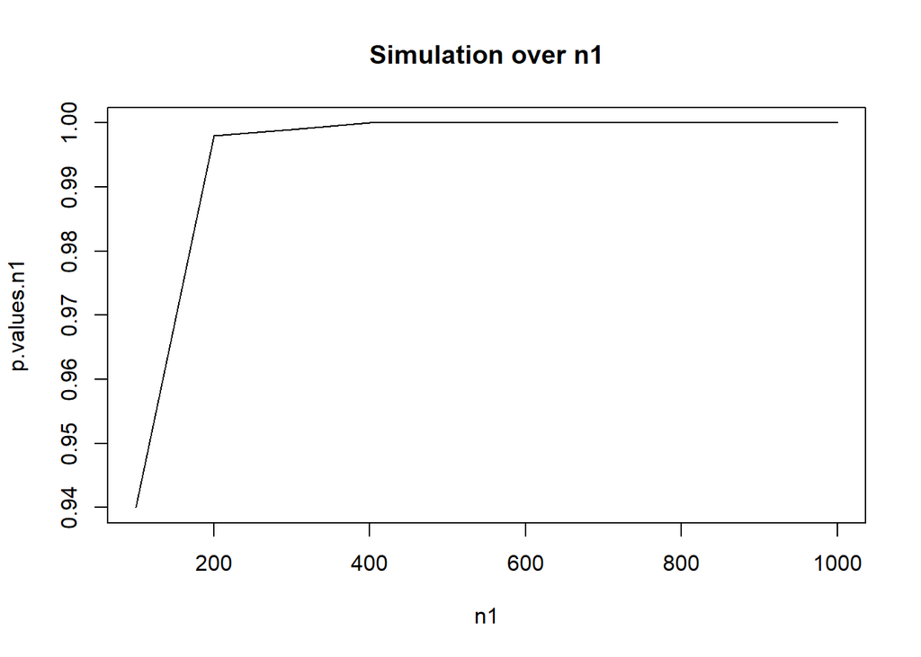

```r
# Simulation over n1
p.values.n1 <- rep(NA, 10)
for(n in 1:10){
  p.values.n1[n] <- mean(simulation(n0, seq(100, 1000, by=100)[n], k, N, M), na.rm=T)
}

plot(seq(100, 1000, by=100), p.values.n1, type="l", xlab="n1", main="Simulation over n1")
```

As we can see the more observations we have of the distributions $F_1$ and the more the p-value grows, this is true because we gain more information about the distribution.

## Simulation over $n_0$

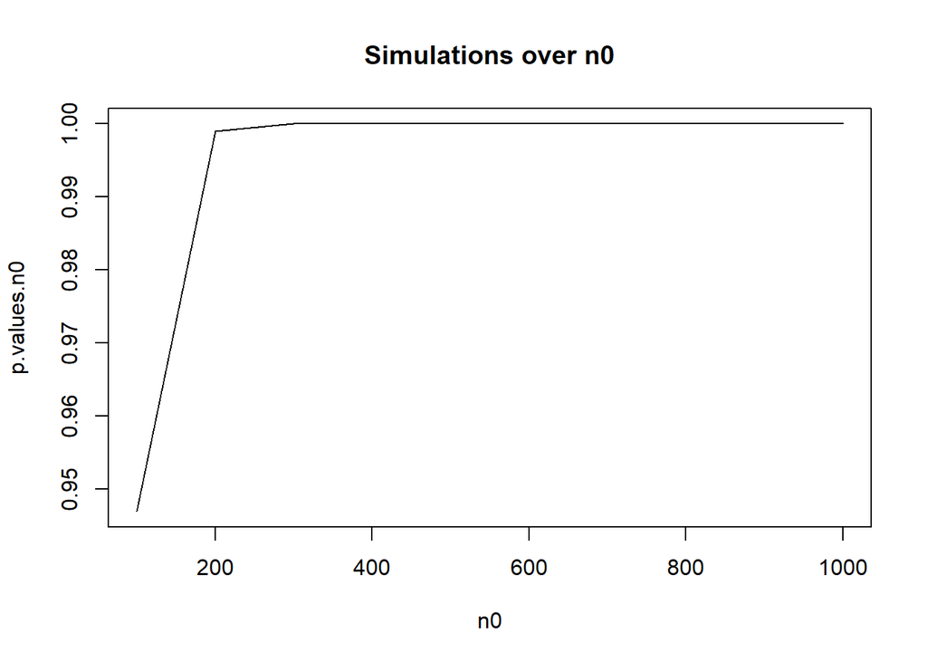

```r
# Simulation over n0
p.values.n0 <- rep(NA, 10)
for(n in 1:10){
  p.values.n0[n] <- mean(simulation(seq(100, 1000, by=100)[n], n1, k, N, M), na.rm=T)
}

plot(seq(100, 1000, by=100), p.values.n0, type="l", xlab="n0", main="Simulations over n0")
```

As for the $F_1$ we can see that the same applies to $F_2$: more observations we have of the distributions $F_2$ and the more the p-value grows, this is true because we gain more information about the distribution.

## Simulation over $k$, $n_1$ and $n_0$

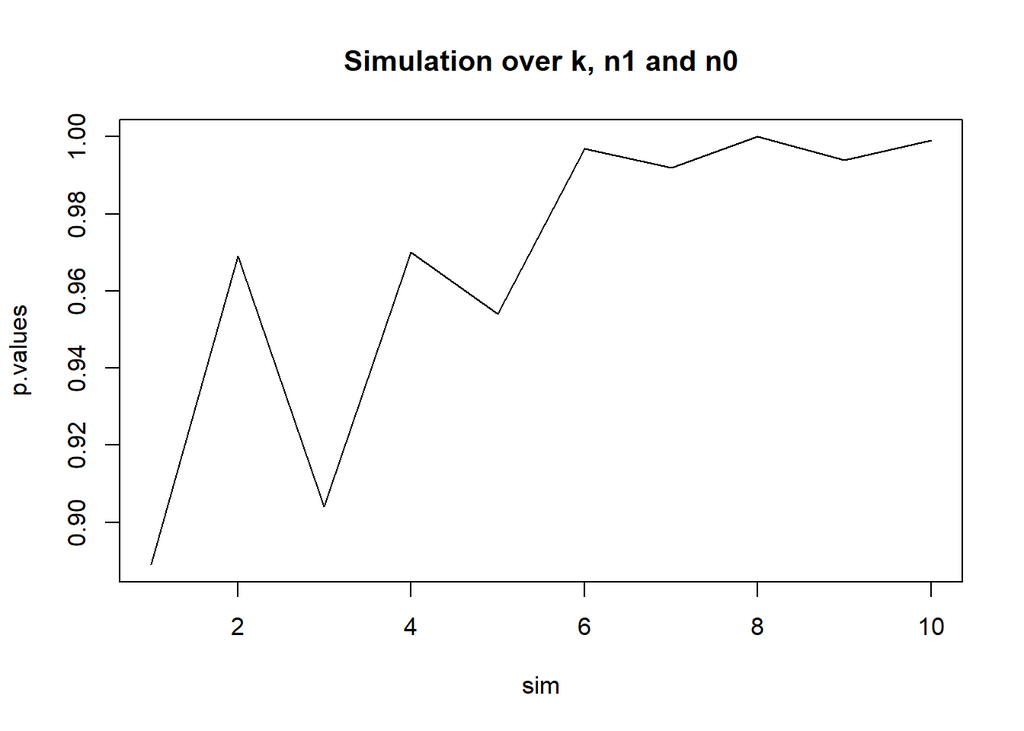

```r
# Simulation over k
p.values <- rep(NA, 10)
for(n in 1:10){
  p.values[n] <- mean(simulation(seq(100, 1000, by=100)[n], seq(100, 1000, by=100)[n], seq(10, 100, by=10)[n], N, M), na.rm=T)
}

plot(p.values, type="l", xlab="sim", main="Simulation over k, n1 and n0")
```

As we can see it is possible that the lost in p-value when $k$ is growing depends mostly on the need of more observation. If we add more observations and we increase $k$ the p-value doesn’t decrease.

# 4 Apply Friedman’s Paper to our dataset

```r
load("hw3_data.RData")
```

## Embedding

```r
library(dplyr)
```

```r
library(rpart.plot)
asd <- data.frame()

for(d in 1:length(asd_data)){

  m <- asd_data[[d]] %>% summarise_if(is.numeric, mean)
  colnames(m) <- sprintf("mean%s", colnames(m))

  v <- asd_data[[d]] %>% summarise_if(is.numeric, var)
  colnames(v) <- sprintf("var%s", colnames(v))

  asd <- rbind(asd, cbind(m, v))

}

td <- data.frame()

for(d in 1:length(td_data)){

  m <- td_data[[d]] %>% summarise_if(is.numeric, mean)
  colnames(m) <- sprintf("mean%s", colnames(m))

  v <- td_data[[d]] %>% summarise_if(is.numeric, var)
  colnames(v) <- sprintf("var%s", colnames(v))

  td <- rbind(td, cbind(m, v))

}

# Adding all the labels
asd$Label <- 0
td$Label <- 1

# Concatenate the two dataframes
df <- rbind(asd, td)
```

## Performing the Friedman’s procedure

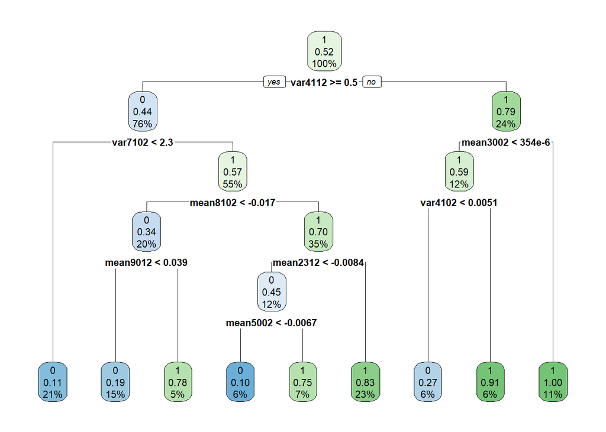

```r
# Train the decision tree
classifier <- rpart(Label ~ ., data = df, method = "class")

# See the classifier
rpart.plot(classifier)
```

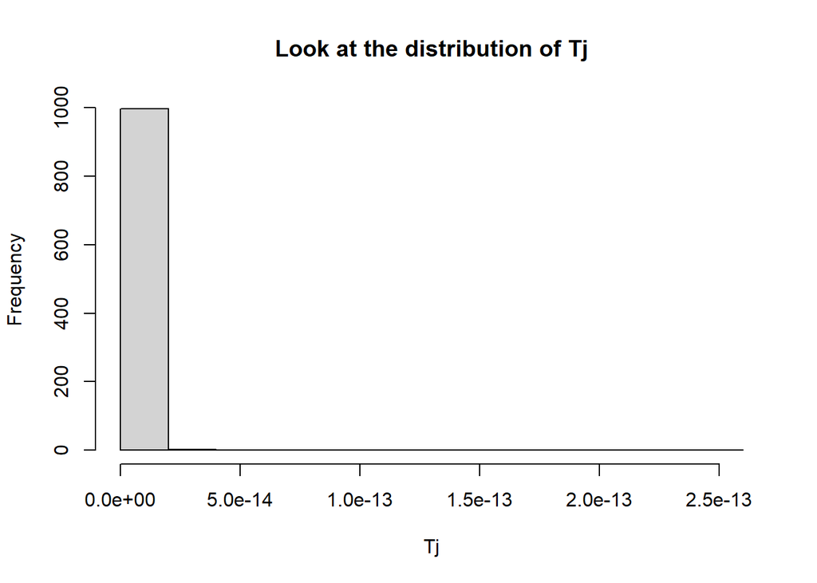

```r
# Predict
df$Predicted <- predict(classifier, df, type = 'class')

s0 <- as.numeric(df[df$Label == 0,]$Predicted)
s1 <- as.numeric(df[df$Label == 1,]$Predicted)

t.hat <- wilcox.test(s0, s1)$p.value

N <- 1000
n0 <- nrow(asd)
n1 <- nrow(td)
test.vect <- rep(NA, N)
for(n in 1:N){
  # We perform the random permutation of the labels
  df$Label = sample(c(rep(0, n0), rep(1, n1)))

  classifier <- rpart(Label ~ . - Predicted, data = df, method = "class")

  df$Predicted <- predict(classifier, df, type = 'class')

  s0 <- as.numeric(df[df$Label == 0,]$Predicted)
  s1 <- as.numeric(df[df$Label == 1,]$Predicted)

  test.vect[n] <- wilcox.test(s0, s1)$p.value
}

p.value <- length(test.vect[test.vect >= t.hat])/N

hist(test.vect, main="Look at the distribution of Tj", xlab = "Tj")
```

```r
print("Do we reject the H0?")
```

```
## [1] "Do we reject the H0?"
```

```r
p.value > 0.05
```

```
## [1] TRUE
```

We decided to use as estimators the mean and the variance of each ROI, this because we thought that those two estimators were enough to classify the brain activity of the two classes: in the last homework we have seen that the two classes differ in the activation of some ROIs. So using the `dplyr` library we performed the mean and the variance for each ROI of each subject and then concatenate each row. In this way we have a representative dataframe for **asd** and **td**. We had a `Label` column in which we save 0 for **asd** and 1 for **td**. We concatenate the two dataframes in one `df` with $116*2+1=233$ columns. Then we implement the Friedman’s procedure setting $N=1000$, we’re able to increment the value of $N$ because we don’t perform any simulation.